# Final Project

Group Project

2023-12-08

Loading in our packages.

```r
library(here)
library(tidyverse)
library(ggplot2)
library(plotly)
library(readxl)
```

First, we will load in all of our data and cut the data frames to hold only the necessary information, and also rename column names for clarity.

```r
rawHolidaySales00to23 = read_excel("statistic_id243439_holiday-retail-sales-in-the-united-states-2000-2023.xlsx", 2)
holidaySales00to23 <- rawHolidaySales00to23[-c(1:2),]
colnames(holidaySales00to23)[1] = "Year"
colnames(holidaySales00to23)[2] = "Sales"
holidaySales00to23$Year <- as.numeric(holidaySales00to23$Year)
holidaySales00to23$Sales <- as.numeric(holidaySales00to23$Sales)
holidaySales00to23$Year[24] <- (2023)

rawRetailSales92to22 = read_excel("statistic_id197576_united-states_-total-retail-sales-in-the-united-states-1992-2022.xlsx", 2)
retailSales92to22 <- rawRetailSales92to22[-c(1:2),]
colnames(retailSales92to22)[1] = "Year"
colnames(retailSales92to22)[2] = "Sales"
retailSales92to22$Year <- as.numeric(retailSales92to22$Year)
retailSales92to22$Sales <- as.numeric(retailSales92to22$Sales)

rawOnlineSales20to23 = read_excel("statistic_id861193_e-commerce-holiday-season-revenue-in-the-us-2019-2023-by-shopping-day.xlsx", 2)
onlineSales20to23 <- rawOnlineSales20to23[-c(1:2),]
colnames(onlineSales20to23)[1] = "Day"
colnames(onlineSales20to23)[2] = "2020 Sales"
colnames(onlineSales20to23)[3] = "2021 Sales"
colnames(onlineSales20to23)[4] = "2022 Sales"
colnames(onlineSales20to23)[5] = "2023 Projected Sales"
onlineSales20to23$`2020 Sales` <- as.numeric(onlineSales20to23$`2020 Sales`)
onlineSales20to23$`2021 Sales` <- as.numeric(onlineSales20to23$`2021 Sales`)
onlineSales20to23$`2022 Sales` <- as.numeric(onlineSales20to23$`2022 Sales`)
onlineSales20to23$`2023 Projected Sales`<- as.numeric(onlineSales20to23$`2023 Projected Sales`)

rawInflationRates60to22 = read_excel("FPCPITOTLZGUSA.xls")
inflationRates60to22 <- rawInflationRates60to22[-c(1:10),]
colnames(inflationRates60to22)[1] = "Year"
colnames(inflationRates60to22)[2] = "Inflation Rate"
inflationRates60to22$Year <- as.numeric(seq.int(from = 1960, to = 2022))
inflationRates60to22$`Inflation Rate` <- as.numeric(inflationRates60to22$`Inflation Rate`)
```

# 1. Do holiday sales actaully increase retail sales by a large margin?

First, we will look at how retail sales and holiday sales look in general, and how they compare to each other.

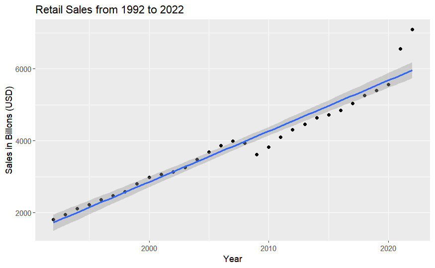

```r
# Retail Sale Scatter Plot
retailSales92to22 = as.data.frame(retailSales92to22)
ggplot(retailSales92to22) +
  aes(x = Year, y = Sales) +
  geom_point() +
  geom_smooth(method = "lm") +
  labs(y = "Sales in Billons (USD)", title = "Retail Sales from 1992 to 2022")
```

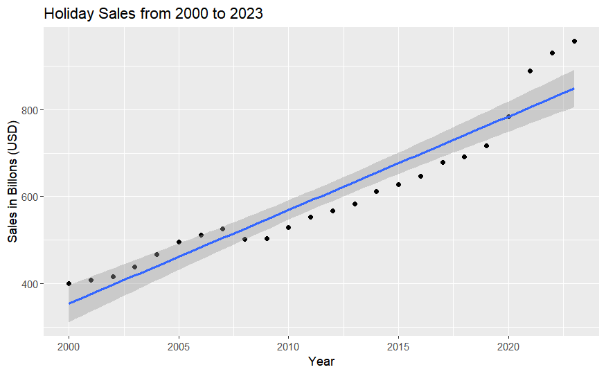

```r
# Holiday Sale Scatter Plot
holidaySales00to23 = as.data.frame(holidaySales00to23)
ggplot(holidaySales00to23) +
  aes(x = Year, y = Sales) +
  geom_point() +
  geom_smooth(method = "lm") +
  labs(y = "Sales in Billons (USD)", title = "Holiday Sales from 2000 to 2023")
```

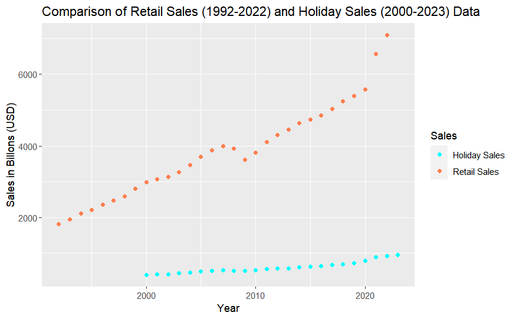

```r
# Comparison
ggplot() +
  geom_point(data = retailSales92to22, aes(x = Year, y = Sales, color = "cyan")) +
  geom_point(data = holidaySales00to23, aes(x = Year, y = Sales, color = "coral")) +
  labs(y = "Sales in Billons (USD)", colour = "Sales", title = "Comparison of Retail Sales (1992-2022) and Holiday Sales (2000-2023) Data") +
  scale_color_manual(values = c("cyan", "coral"),
                     labels = c("Holiday Sales", "Retail Sales"))
```

In order to get an effective result, we will cut both data frames so that the data is focusing only on the years 2010-2020. Anything before 2010 is a little too old. In regards to the years 2021 and 2022, reasons for exclusion are discussed in our paper.

```r
retailSales10to20 <- retailSales92to22[-c(1:18,30:31),]
holidaySales10to20 <- holidaySales00to23[-c(1:10, 22:24),]
```

Now, we will repeat the same process for the new data frames.

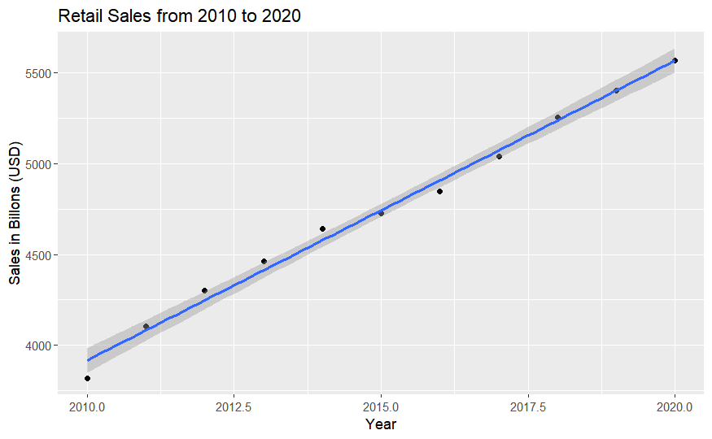

```r
# Retail Sale Scatter Plot
ggplot(retailSales10to20) +
  aes(x = Year, y = Sales) +
  geom_point() +
  geom_smooth(method = "lm") +
  labs(y = "Sales in Billons (USD)", title = "Retail Sales from 2010 to 2020")
```

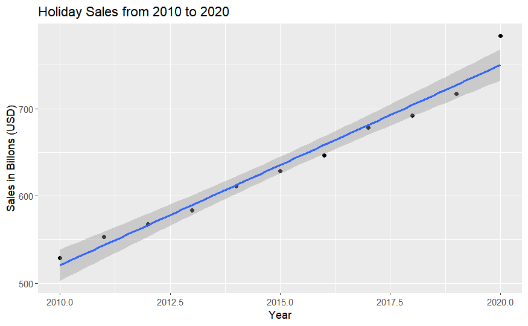

```r
# Holiday Sale Scatter Plot
ggplot(holidaySales10to20) +
  aes(x = Year, y = Sales) +
  geom_point() +
  geom_smooth(method = "lm")+
  labs(y = "Sales in Billons (USD)", title = "Holiday Sales from 2010 to 2020")
```

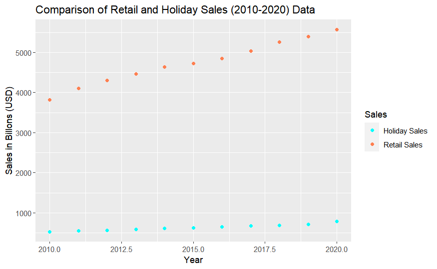

```r
# Comparison
ggplot() +
  geom_point(data = retailSales10to20, aes(x = Year, y = Sales, color = "cyan")) +
  geom_point(data = holidaySales10to20, aes(x = Year, y = Sales, color = "coral")) +
  labs(y = "Sales in Billons (USD)", colour = "Sales", title = "Comparison of Retail and Holiday Sales (2010-2020) Data") +
  scale_color_manual(values = c("cyan", "coral"),
                     labels = c("Holiday Sales", "Retail Sales"))
```

```r
lmRetailSales10to20 <- lm(Sales ~ Year, data = retailSales10to20)
summary(lmRetailSales10to20)
```

```
Call:
lm(formula = Sales ~ Year, data = retailSales10to20)

Residuals:
    Min      1Q  Median      3Q     Max
-98.027 -23.853   1.078  34.676  64.559

Coefficients:
              Estimate Std. Error t value Pr(>|t|)
(Intercept) -3.284e+05  1.008e+04  -32.57 1.19e-10 ***
Year         1.653e+02  5.003e+00   33.05 1.05e-10 ***
---
Signif. codes:  0 ‘***’ 0.001 ‘**’ 0.01 ‘*’ 0.05 ‘.’ 0.1 ‘ ’ 1

Residual standard error: 52.47 on 9 degrees of freedom
Multiple R-squared:  0.9918,    Adjusted R-squared:  0.9909
F-statistic:  1092 on 1 and 9 DF,  p-value: 1.048e-10
```

```r
lmHolidaySales10to20 <- lm(Sales ~ Year, data = holidaySales10to20)
summary(lmHolidaySales10to20)
```

```
Call:
lm(formula = Sales ~ Year, data = holidaySales10to20)

Residuals:
    Min      1Q  Median      3Q     Max
-12.408  -8.860  -3.160   4.629  33.295

Coefficients:
              Estimate Std. Error t value Pr(>|t|)
(Intercept) -45605.223   2695.563  -16.92 3.95e-08 ***
Year            22.948      1.338   17.15 3.50e-08 ***
---
Signif. codes:  0 ‘***’ 0.001 ‘**’ 0.01 ‘*’ 0.05 ‘.’ 0.1 ‘ ’ 1

Residual standard error: 14.03 on 9 degrees of freedom
Multiple R-squared:  0.9703,    Adjusted R-squared:  0.967
F-statistic: 294.3 on 1 and 9 DF,  p-value: 3.499e-08
```

We will subtract the holiday sales from the retail sales to see how much retail sales are without taking holiday sales into account.

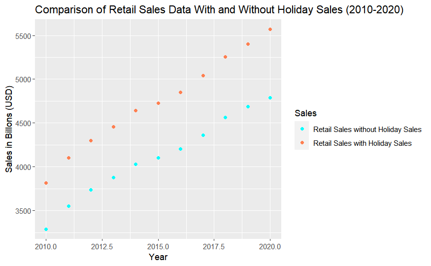

```r
retailSales10to20$SalesWithoutHoliday <- (retailSales10to20$Sales - holidaySales10to20$Sales)

ggplot() +
  geom_point(data = retailSales10to20, aes(x = Year, y = Sales, color = "cyan")) +
  geom_point(data = retailSales10to20, aes(x = Year, y = SalesWithoutHoliday, color = "coral")) +
  labs(y = "Sales in Billons (USD)", colour = "Sales", title = "Comparison of Retail Sales Data With and Without Holiday Sales (2010-2020)") +
  scale_color_manual(values = c("cyan", "coral"),
                     labels = c("Retail Sales without Holiday Sales", "Retail Sales with Holiday Sales"))
```

As we can see from the data, the retail sales are affected pretty heavily from holiday sales.

# 2. Do holiday online sales have an influence on the total sales for the holidays?

We will take the holiday sales and online sales data to better answer this question. We will see if online sales hold a majority of that influence on holiday sales. We will only take into account years 2020-2023, as that is the only data we have. For the 2023, we only have projected data, so we will use that as well.

```r
onlineSales20to23 <- rbind(onlineSales20to23, c("Total Sales", as.numeric(sum(onlineSales20to23$`2020 Sales`)), as.numeric(sum(onlineSales20to23$`2021 Sales`)), as.numeric(sum(onlineSales20to23$`2022 Sales`)), as.numeric(sum(onlineSales20to23$`2023 Projected Sales`))))
```

```r
onlineSales20to23[4,]
```

| Day | 2020 Sales | 2021 Sales | 2022 Sales | 2023 Projected Sales |
| --- | --- | --- | --- | --- |
| Total Sales | 24.9 | 26.34 | 24.74 | 27.2 |

Now we will subtract the online sales from the total holiday sales.

```r
holidaySales00to23$InPersonSales <- (NA)
holidaySales00to23$InPersonSales[21] <- (holidaySales00to23$Sales[21] - as.numeric(onlineSales20to23$`2020 Sales`[4]))
holidaySales00to23$InPersonSales[21]
```

```
[1] 758.5
```

```r
holidaySales00to23$InPersonSales[22] <- (holidaySales00to23$Sales[22] - as.numeric(onlineSales20to23$`2021 Sales`[4]))
holidaySales00to23$InPersonSales[22]
```

```
[1] 862.96
```

```r
holidaySales00to23$InPersonSales[23] <- (holidaySales00to23$Sales[23] - as.numeric(onlineSales20to23$`2022 Sales`[4]))
holidaySales00to23$InPersonSales[23]
```

```
[1] 904.76
```

```r
holidaySales00to23$InPersonSales[24] <- (holidaySales00to23$Sales[24] - as.numeric(onlineSales20to23$`2023 Projected Sales`[4]))
holidaySales00to23$InPersonSales[24]
```

```
[1] 930.1
```

We will graph the differences to see how big of a difference it is between online and in-person holiday sales.

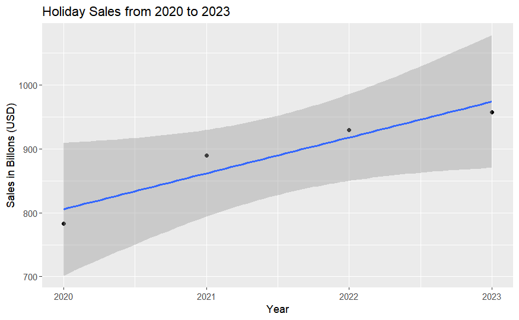

```r
holidaySales20to23 <- holidaySales00to23[-c(1:20),]
holidaySales20to23$Year <- as.numeric(holidaySales20to23$Year)
holidaySales20to23$Sales <- as.numeric(holidaySales20to23$Sales)
holidaySales20to23$InPersonSales <- as.numeric(holidaySales20to23$InPersonSales)

ggplot(holidaySales20to23) +
  aes(x = Year, y = Sales) +
  geom_point() +
  geom_smooth(method = "lm") +
  labs(y = "Sales in Billons (USD)", title = "Holiday Sales from 2020 to 2023")
```

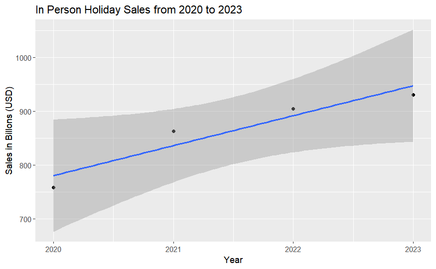

```r
ggplot(holidaySales20to23) +
  aes(x = Year, y = InPersonSales) +
  geom_point() +
  geom_smooth(method = "lm") +
  labs(y = "Sales in Billons (USD)", title = "In Person Holiday Sales from 2020 to 2023")
```

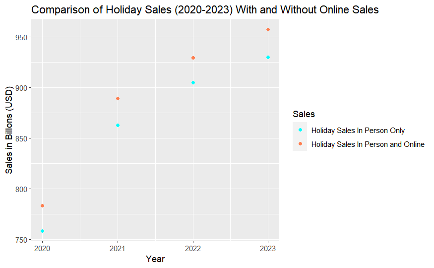

```r
ggplot() +
  geom_point(data = holidaySales20to23, aes(x = Year, y = Sales, color = "cyan")) +
  geom_point(data = holidaySales20to23, aes(x = Year, y = InPersonSales, color = "coral")) +
  labs(y = "Sales in Billons (USD)", colour = "Sales", title = "Comparison of Holiday Sales (2020-2023) With and Without Online Sales") +
  scale_color_manual(values = c("cyan", "coral"),
                     labels = c("Holiday Sales In Person Only", "Holiday Sales In Person and Online"))
```

```r
lmHolidaySales20to23 <- lm(Sales ~ Year, data = holidaySales20to23)
summary(lmHolidaySales20to23)
```

```
Call:
lm(formula = Sales ~ Year, data = holidaySales20to23)

Residuals:
    21     22     23     24
-22.19  27.52  11.53 -16.86

Coefficients:
              Estimate Std. Error t value Pr(>|t|)
(Intercept) -112698.21   26099.65  -4.318   0.0497 *
Year             56.19      12.91   4.352   0.0490 *
---
Signif. codes:  0 ‘***’ 0.001 ‘**’ 0.01 ‘*’ 0.05 ‘.’ 0.1 ‘ ’ 1

Residual standard error: 28.87 on 2 degrees of freedom
Multiple R-squared:  0.9045,    Adjusted R-squared:  0.8567
F-statistic: 18.94 on 1 and 2 DF,  p-value: 0.04895
```

```r
lmInPersonHolidaySales10to20 <- lm(InPersonSales ~ Year, data = holidaySales20to23)
summary(lmInPersonHolidaySales10to20)
```

```
Call:
lm(formula = InPersonSales ~ Year, data = holidaySales20to23)

Residuals:
    21     22     23     24
-22.09  26.71  12.85 -17.47

Coefficients:
              Estimate Std. Error t value Pr(>|t|)
(Intercept) -111652.61   26136.96  -4.272   0.0507 .
Year             55.66      12.93   4.305   0.0500 *
---
Signif. codes:  0 ‘***’ 0.001 ‘**’ 0.01 ‘*’ 0.05 ‘.’ 0.1 ‘ ’ 1

Residual standard error: 28.91 on 2 degrees of freedom
Multiple R-squared:  0.9026,    Adjusted R-squared:  0.8539
F-statistic: 18.53 on 1 and 2 DF,  p-value: 0.04995
```

We can see, that it is not much of a difference in sales. If people did not shop online at all, the loss would not be very significant.

#3. Are people actually spending more on holiday spending as the years progress, or are they other reasons for this? Is inflation the reason for this assumed “increase”?

We will begin by subtracting the inflation from the holiday sales over the years 2000 to 2022.

```r
holidaySales00to23$SalesWithoutInflation <- (NA)
holidaySales00to23$SalesWithoutInflation[1] <- (holidaySales00to23$Sales[1] - (holidaySales00to23$Sales[1] * (inflationRates60to22$`Inflation Rate`[41] / 100)))

holidaySales00to23$SalesWithoutInflation[2] <- (holidaySales00to23$Sales[2] - (holidaySales00to23$Sales[2] * (inflationRates60to22$`Inflation Rate`[42] / 100)))

holidaySales00to23$SalesWithoutInflation[3] <- (holidaySales00to23$Sales[3] - (holidaySales00to23$Sales[3] * (inflationRates60to22$`Inflation Rate`[43] / 100)))

holidaySales00to23$SalesWithoutInflation[4] <- (holidaySales00to23$Sales[4] - (holidaySales00to23$Sales[4] * (inflationRates60to22$`Inflation Rate`[44] / 100)))

holidaySales00to23$SalesWithoutInflation[5] <- (holidaySales00to23$Sales[5] - (holidaySales00to23$Sales[5] * (inflationRates60to22$`Inflation Rate`[45] / 100)))

holidaySales00to23$SalesWithoutInflation[6] <- (holidaySales00to23$Sales[6] - (holidaySales00to23$Sales[6] * (inflationRates60to22$`Inflation Rate`[46] / 100)))

holidaySales00to23$SalesWithoutInflation[7] <- (holidaySales00to23$Sales[7] - (holidaySales00to23$Sales[7] * (inflationRates60to22$`Inflation Rate`[47] / 100)))

holidaySales00to23$SalesWithoutInflation[8] <- (holidaySales00to23$Sales[8] - (holidaySales00to23$Sales[8] * (inflationRates60to22$`Inflation Rate`[48] / 100)))

holidaySales00to23$SalesWithoutInflation[9] <- (holidaySales00to23$Sales[9] - (holidaySales00to23$Sales[9] * (inflationRates60to22$`Inflation Rate`[49] / 100)))

holidaySales00to23$SalesWithoutInflation[10] <- (holidaySales00to23$Sales[10] - (holidaySales00to23$Sales[10] * (inflationRates60to22$`Inflation Rate`[50] / 100)))

holidaySales00to23$SalesWithoutInflation[11] <- (holidaySales00to23$Sales[11] - (holidaySales00to23$Sales[11] * (inflationRates60to22$`Inflation Rate`[51] / 100)))

holidaySales00to23$SalesWithoutInflation[12] <- (holidaySales00to23$Sales[12] - (holidaySales00to23$Sales[12] * (inflationRates60to22$`Inflation Rate`[52] / 100)))

holidaySales00to23$SalesWithoutInflation[13] <- (holidaySales00to23$Sales[13] - (holidaySales00to23$Sales[13] * (inflationRates60to22$`Inflation Rate`[53] / 100)))

holidaySales00to23$SalesWithoutInflation[14] <- (holidaySales00to23$Sales[14] - (holidaySales00to23$Sales[14] * (inflationRates60to22$`Inflation Rate`[54] / 100)))

holidaySales00to23$SalesWithoutInflation[15] <- (holidaySales00to23$Sales[15] - (holidaySales00to23$Sales[15] * (inflationRates60to22$`Inflation Rate`[55] / 100)))

holidaySales00to23$SalesWithoutInflation[16] <- (holidaySales00to23$Sales[16] - (holidaySales00to23$Sales[16] * (inflationRates60to22$`Inflation Rate`[56] / 100)))

holidaySales00to23$SalesWithoutInflation[17] <- (holidaySales00to23$Sales[17] - (holidaySales00to23$Sales[17] * (inflationRates60to22$`Inflation Rate`[57] / 100)))

holidaySales00to23$SalesWithoutInflation[18] <- (holidaySales00to23$Sales[18] - (holidaySales00to23$Sales[18] * (inflationRates60to22$`Inflation Rate`[58] / 100)))

holidaySales00to23$SalesWithoutInflation[19] <- (holidaySales00to23$Sales[19] - (holidaySales00to23$Sales[19] * (inflationRates60to22$`Inflation Rate`[59] / 100)))

holidaySales00to23$SalesWithoutInflation[20] <- (holidaySales00to23$Sales[20] - (holidaySales00to23$Sales[20] * (inflationRates60to22$`Inflation Rate`[60] / 100)))

holidaySales00to23$SalesWithoutInflation[21] <- (holidaySales00to23$Sales[21] - (holidaySales00to23$Sales[21] * (inflationRates60to22$`Inflation Rate`[61] / 100)))

holidaySales00to23$SalesWithoutInflation[22] <- (holidaySales00to23$Sales[22] - (holidaySales00to23$Sales[22] * (inflationRates60to22$`Inflation Rate`[62] / 100)))

holidaySales00to23$SalesWithoutInflation[23] <- (holidaySales00to23$Sales[23] - (holidaySales00to23$Sales[23] * (inflationRates60to22$`Inflation Rate`[63] / 100)))
```

Some of the values for Sales Without Inflation are higher than their respectively sales because the inflation rate was negative, which will be discussed in our paper. Short answer is that the value of the US dollar was worth more, so the lower inflation rate accounted for that. If the inflation rate was a positive number, then that means are dollar was not worth enough to meet what is around the 0 mark.

Now, we will graph the sales and sales without inflation seperately, and together, to compare values.

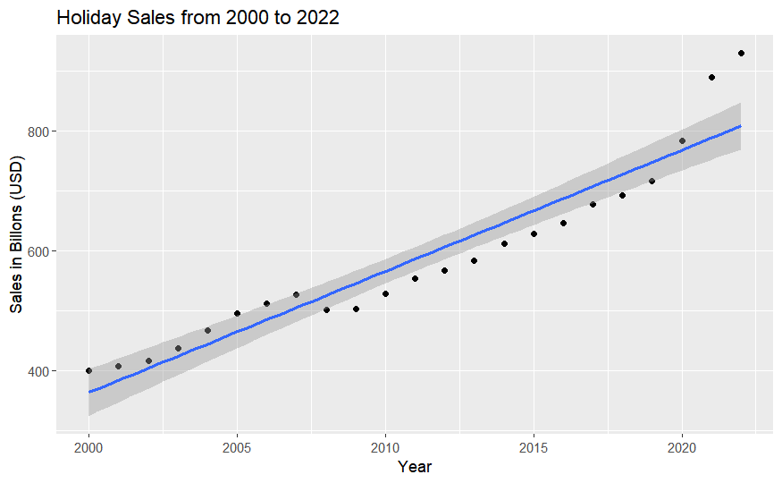

```r
holidaySales00to22 <- holidaySales00to23[-c(24),]
ggplot(holidaySales00to22) +
  aes(x = Year, y = Sales) +
  geom_point() +
  geom_smooth(method = "lm") +
  labs(y = "Sales in Billons (USD)", title = "Holiday Sales from 2000 to 2022")
```

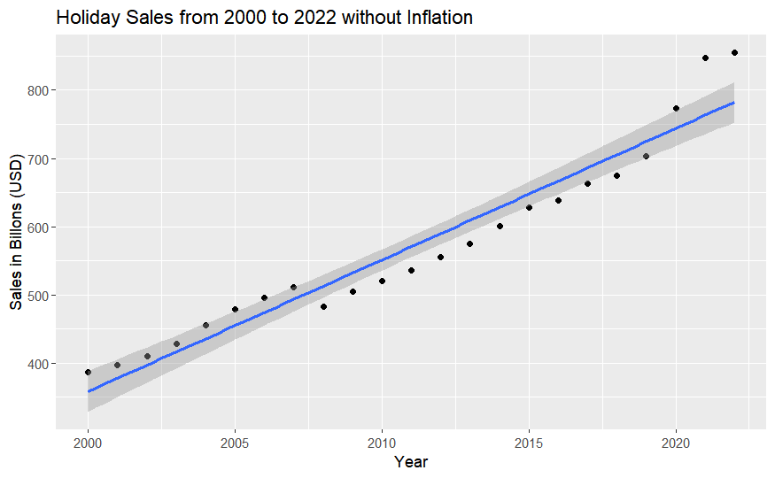

```r
ggplot(holidaySales00to22) +
  aes(x = Year, y = SalesWithoutInflation) +
  geom_point() +
  geom_smooth(method = "lm") +
  labs(y = "Sales in Billons (USD)", title = "Holiday Sales from 2000 to 2022 without Inflation")
```

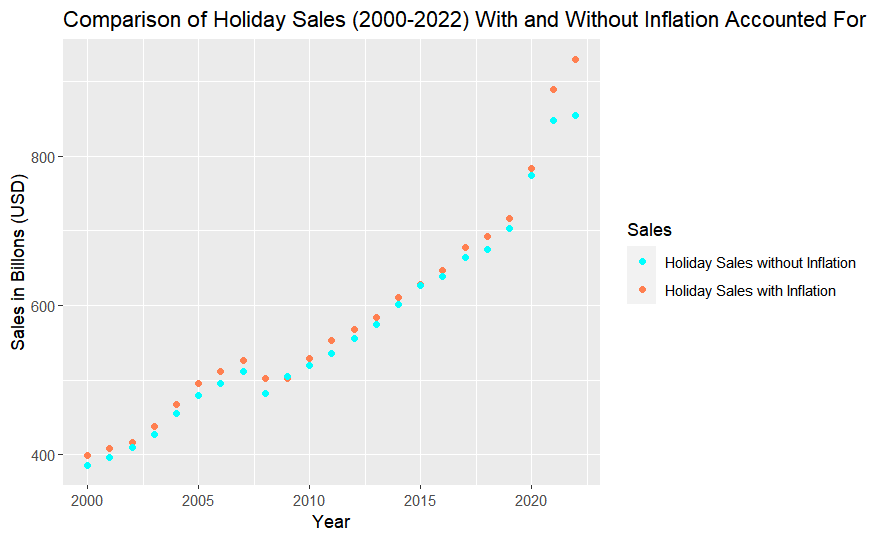

```r
ggplot() +
  geom_point(data = holidaySales00to22, aes(x = Year, y = Sales, color = "cyan")) +
  geom_point(data = holidaySales00to22, aes(x = Year, y = SalesWithoutInflation, color = "coral")) +
  labs(y = "Sales in Billons (USD)", colour = "Sales", title = "Comparison of Holiday Sales (2000-2022) With and Without Inflation Accounted For") +
  scale_color_manual(values = c("cyan", "coral"),
                     labels = c("Holiday Sales without Inflation", "Holiday Sales with Inflation"))
```

```r
lmHolidaySales00to22 <- lm(Sales ~ Year, data = holidaySales00to22)
summary(lmHolidaySales00to22)
```

```
Call:
lm(formula = Sales ~ Year, data = holidaySales00to22)

Residuals:
   Min     1Q Median     3Q    Max
-42.98 -36.19 -23.71  23.45 121.30

Coefficients:
              Estimate Std. Error t value Pr(>|t|)
(Intercept) -40063.114   2948.224  -13.59 7.12e-12 ***
Year            20.213      1.466   13.79 5.40e-12 ***
---
Signif. codes:  0 ‘***’ 0.001 ‘**’ 0.01 ‘*’ 0.05 ‘.’ 0.1 ‘ ’ 1

Residual standard error: 46.64 on 21 degrees of freedom
Multiple R-squared:  0.9005,    Adjusted R-squared:  0.8958
F-statistic: 190.1 on 1 and 21 DF,  p-value: 5.402e-12
```

```r
lmInflationHolidaySales00to22 <- lm(SalesWithoutInflation ~ Year, data = holidaySales00to22)
summary(lmInflationHolidaySales00to22)
```

```
Call:
lm(formula = SalesWithoutInflation ~ Year, data = holidaySales00to22)

Residuals:
   Min     1Q Median     3Q    Max
-34.57 -29.30 -20.20  20.45  84.25

Coefficients:
              Estimate Std. Error t value Pr(>|t|)
(Intercept) -38215.321   2240.350  -17.06 8.80e-14 ***
Year            19.287      1.114   17.31 6.58e-14 ***
---
Signif. codes:  0 ‘***’ 0.001 ‘**’ 0.01 ‘*’ 0.05 ‘.’ 0.1 ‘ ’ 1

Residual standard error: 35.44 on 21 degrees of freedom
Multiple R-squared:  0.9345,    Adjusted R-squared:  0.9314
F-statistic: 299.7 on 1 and 21 DF,  p-value: 6.577e-14
```

While we suspected that the holiday sales would be a flat line, due to inflation accounting for the price increase, they are not. The sales are still increasing with inflation accounted for.

Interestingly, we found that years 2009 and 2015 had almost no change when inflation rate was accounted for, which makes sense as they had the two closest values to 0.